# Is Veganism Really That Good for The Environment???

## A Walkthrough Tutorial of the Data Science Pipeline!

### Using meat consumption to predict CO2 emissions

It seems that as the years go on, we are seeing more and more evidence of the impending doom of climate change and while there are many factors contributing to it, for this tutorial I decided to focus on the role of meat consumption's role in the environment, specifcally on carbon dioxide emissions.

Currently, meat consumption in developed countries is about [5 times higher than the recommended amount](https://www.standard.co.uk/lifestyle/no-kids-better-for-the-environment-a4198451.html), and it seems as though meat consumption continues to increase as countries become more and more developed. However, there also seems to be an increased interest in more plant-based lifestyles. Although many may choose to go vegan or vegetarian for health reasons or out of empathy for the animals, another commonly cited reason to reduce meat consumption is to reduce our enviornmental impact. So I wanted to explore, how helpful is reducing meat consumption, really?

> Meat consumption can be used to predict carbon dioxide emissions and thus plays a significant role in our environment.

We will accomplish this by walking through the steps of the data science pipeline which are as follows:

1. Data collection/curation + parsing
2. Data management/representation
3. Exploratory data analysis
4. Hypothesis testing and machine learning (specifically, using a regression model)
5. Communication of insights attained

*Disclaimer* I am not vegan, nor am I vegetarian, I just thought this would be a fun way to present this tutorial as I am genuinely interested in how big of a role meat consumption plays in our environment and whether it is truly significant enough predict things like CO2 emissions. So let's Dive in!

## Data Collection/Curation

We will be using a compilation of the following datasets in this tutorial downloaded from the following websites:

- Total CO2 Emissions(in Kg) of Different Food Products: https://www.kaggle.com/selfvivek/environment-impact-of-food-production
- Annual CO2 Emissions (in Tons) by Country: https://www.kaggle.com/yoannboyere/co2-ghg-emissionsdata
- Meat Consumption (in Kg/person) by Country: https://data.oecd.org/agroutput/meat-consumption.htm
- Population by Country from 1990-2021: https://www.census.gov/data-tools/demo/idb/#/table?YR_ANIM=2040&menu=tableViz&TABLE_RANGE=1990,2020&TABLE_YEARS=1990,1991,1992,1993,1994,1995,1996,1997,1998,1999,2000,2001,2002,2003,2004,2005,2006,2007,2008,2009,2010,2011,2012,2013,2014,2015,2016,2017,2018,2019,2020,2021&TABLE_USE_RANGE=Y&TABLE_USE_YEARS=Y&TABLE_STEP=1&TABLE_ADD_YEARS=2021

```python
# Importing the libraries we will be using

# the ultimate tool for working with dataframes
import pandas as pd
#  a helpful scientific computing library whihc help us with our numbers and stats
import numpy as np
# libraries we will be using for plotting!
import matplotlib.pyplot as plt
import seaborn as sns
# a powerful library that will simplify building our machine learning models!
import sklearn
from sklearn.model_selection import train_test_split
from sklearn.linear_model import LinearRegression
plt.rcParams["figure.figsize"] = (14, 6)
```

```python
food_impact = pd.read_csv('../Food_Production.csv', sep=',')
# in this dataset all we care about is the product column and total_emissions column
food_impact = food_impact[['Food product', 'Total_emissions']]
food_impact.head()
```

|  | Food product | Total_emissions |
| --- | --- | --- |
| 0 | Wheat & Rye (Bread) | 1.4 |
| 1 | Maize (Meal) | 1.1 |
| 2 | Barley (Beer) | 1.1 |
| 3 | Oatmeal | 1.6 |
| 4 | Rice | 4.0 |

Right away, I wanted to visualize the food_impact data to get a true idea of the carbon emissions associated with each type of food product.

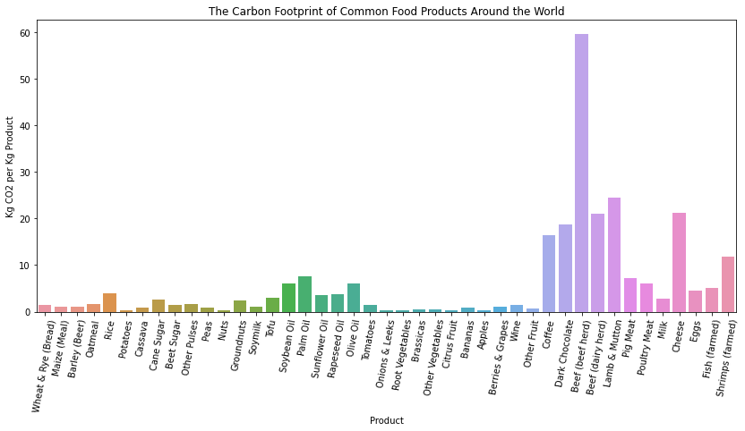

```python
food_bar = sns.barplot(data=food_impact, x="Food product", y="Total_emissions")
plt.title('The Carbon Footprint of Common Food Products Around the World')
plt.xlabel('Product')
plt.ylabel('Kg CO2 per Kg Product')
food_bar.set_xticklabels(food_bar.get_xticklabels(), rotation=80)
plt.show()
```

As shown above, it is clear that animal products (on the right side of the graph), tend to emit much higher amounts of carbon dioxide per kilogram (especially beef!) than the plant-based products seen on the left. Hearing about the differences between these foods is the main motivation behind this data exploration, and why I want to see if meat consumption can truly be used to predict CO2 emissions and make an impact on our planet.

We will using this data mostly as a conversion factor to make displaying the rest of our data simpler.

For this tutorial we will focus on Beef, Sheep, Pork, and Poultry as our "meat" so we will subset the dataframe as follows:

```python
# subsetting meat emissions to just Beef meat, Sheep, Pork and Poultry
food_impact = food_impact[(food_impact['Food product'] == 'Beef (beef herd)') | (food_impact['Food product'] == 'Lamb & Mutton') | (food_impact['Food product'] == 'Pig Meat') | (food_impact['Food product'] == 'Poultry Meat')]
food_impact.columns = ['Product', 'kG CO2 emitted per kG Product']
# rename to BEEF, SHEEP, PIG, POULTRY to match our other datasets
food_impact['Product'] = ['BEEF', 'SHEEP', 'PIG', 'POULTRY']
food_impact
```

|  | Product | kG CO2 emitted per kG Product |
| --- | --- | --- |
| 33 | BEEF | 59.6 |
| 35 | SHEEP | 24.5 |
| 36 | PIG | 7.2 |
| 37 | POULTRY | 6.1 |

Reading in our (overall) annual CO2 emissions per country table which goes from 1949-2017.

```python
#1949-2017
co2 = pd.read_csv('../co2_emission.csv', sep = ',')
co2.head()
```

|  | Entity | Code | Year | Annual CO₂ emissions (tonnes ) |
| --- | --- | --- | --- | --- |
| 0 | Afghanistan | AFG | 1949 | 14656.0 |
| 1 | Afghanistan | AFG | 1950 | 84272.0 |
| 2 | Afghanistan | AFG | 1951 | 91600.0 |
| 3 | Afghanistan | AFG | 1952 | 91600.0 |
| 4 | Afghanistan | AFG | 1953 | 106256.0 |

Next we will read in a csv containing the amount of meat consumed per capita (in kilograms) for each country from 1990-2029. Because this obviously includes projected data, we will be subsetting that out to make sure our model is as accurate as possible.

```python
#1990-2029 (projection)
consumption = pd.read_csv('../DP_LIVE_18072021152309687.csv', sep=',')
# I'm interested in meat consumption measured by Kg/capita
consumption = consumption[consumption['MEASURE'] == 'KG_CAP']
# don't care about indicator/measure/frequency or flag code columns (don't tell us anything)
consumption = consumption[['LOCATION', 'SUBJECT', 'TIME', 'Value']]
# value is in kg/capita --let's rename for better clarity
consumption.columns = ['LOCATION', 'SUBJECT', 'TIME', 'Consumption (kG/Capita)']
# since this datasets includes projects into 2029 I want to subset it until 2020 only so that we have only real already observed data
consumption = consumption[consumption['TIME'] < 2021].sort_values(by=['LOCATION', 'TIME'])
# drop redundant product column
consumption.head()
```

|  | LOCATION | SUBJECT | TIME | Consumption (kG/Capita) |
| --- | --- | --- | --- | --- |
| 1280 | ARG | BEEF | 1990 | 55.559 |
| 1320 | ARG | PIG | 1990 | 3.674 |
| 1360 | ARG | POULTRY | 1990 | 8.660 |
| 1400 | ARG | SHEEP | 1990 | 2.282 |
| 1281 | ARG | BEEF | 1991 | 51.817 |

## Data Management/Representation

Immediately I notice that the Annual Overall CO2 emissions dataset is measured in tons while the others are measured in kilograms, so my immediate game plan is to convert all the kG CO2 data into tons of CO2 by converting the measurement from a per capita basis, to a whole country basis, by using the population of each country. This way I can represent all CO2 emissions using tons and more easily compare the CO2 emissions specifically coming from meat with overall CO2 emissions. Ideally, I would like to merge all this into one big dataframe, but we will do this in steps.

First, I will merge the food_impact dataframe containg kilograms CO2 emitted per kilogram of product with the meat_consumption dataframe.

```python
consumption_impact = pd.merge(consumption, food_impact, left_on = ['SUBJECT'], right_on = ['Product'])
#sorting by country code and time
consumption_impact = consumption_impact.sort_values(by=['LOCATION', 'TIME'])
# drop redundant product column
consumption_impact = consumption_impact.drop(['Product'], axis = 1)
# renaming columns
consumption_impact.columns = ['country_code', 'meat_product', 'year', 'consumption(kg/capita)', 'kg_CO2/kg_product' ]
consumption_impact.head()
```

|  | country_code | meat_product | year | consumption(kg/capita) | kg_CO2/kg_product |
| --- | --- | --- | --- | --- | --- |
| 0 | ARG | BEEF | 1990 | 55.559 | 59.6 |
| 1178 | ARG | PIG | 1990 | 3.674 | 7.2 |
| 2356 | ARG | POULTRY | 1990 | 8.660 | 6.1 |
| 3534 | ARG | SHEEP | 1990 | 2.282 | 24.5 |
| 1 | ARG | BEEF | 1991 | 51.817 | 59.6 |

Now I'm going to use the environmental impact column (kg_Co2/kg_product) in order to calculate a column which contains the actual amount of CO2 emitted per person based on meat consumption per person.

```python
# multiply last 2 columns together
consumption_impact['kg_CO2/capita'] = ''
for index, row in consumption_impact.iterrows():
    consumption_impact.at[index,'kg_CO2/capita'] = consumption_impact.at[index,'consumption(kg/capita)'] * consumption_impact.at[index,'kg_CO2/kg_product']
# we can now drop the kg_CO2/kg_product column since this was essentially just used for conversion
consumption_impact = consumption_impact.drop(['kg_CO2/kg_product'], axis=1)
consumption_impact.head()
```

|  | country_code | meat_product | year | consumption(kg/capita) | kg_CO2/capita |
| --- | --- | --- | --- | --- | --- |
| 0 | ARG | BEEF | 1990 | 55.559 | 3311.32 |
| 1178 | ARG | PIG | 1990 | 3.674 | 26.4528 |
| 2356 | ARG | POULTRY | 1990 | 8.660 | 52.826 |
| 3534 | ARG | SHEEP | 1990 | 2.282 | 55.909 |
| 1 | ARG | BEEF | 1991 | 51.817 | 3088.29 |

I am not interested in distinguishing between beef, pig, poultry, and sheep meat. Originally, these distintions were useful to calculate the amount of CO2 produced per kilogram, but now that we have that, I am going to merge the 4 rows into 1 by summing the kilograms consumed together, and then separately summing the kilograms of carbon dioxide produced as a result of that.

```python
# now I want to create a table that combines Beef/Pig/Poultry/Sheep consumption and co2 emission into 1 row (rather than 4 seperate rows for each meat type)
total_meat_impact = consumption_impact.groupby(['country_code', 'year'], as_index=False).agg({"consumption(kg/capita)": "sum", "kg_CO2/capita": "sum"})
total_meat_impact.head()
```

|  | country_code | year | consumption(kg/capita) | kg_CO2/capita |
| --- | --- | --- | --- | --- |
| 0 | ARG | 1990 | 70.175 | 3446.5042 |
| 1 | ARG | 1991 | 66.656 | 3225.9691 |
| 2 | ARG | 1992 | 67.388 | 3178.2821 |
| 3 | ARG | 1993 | 73.840 | 3254.9227 |
| 4 | ARG | 1994 | 74.197 | 3101.3830 |

Now I want to merge this with our dataframe containing overall CO2 emissions per country. This merge will cause a reduction in the amount of years contained in the annual CO2 emissions we had originally (which went all the way back to 1949), but this is ok for our purposes, because we only want to analyze the data that is available to us for comparison.

```python
# now lets merge this with our country data on total Co2 emissions
meat_co2 = pd.merge(co2, total_meat_impact, left_on = ['Code', 'Year'], right_on=['country_code', 'year'])
#drop redundant country code and year columns (will be duplicated)
meat_co2.drop(['country_code', 'year'], axis=1)
meat_co2.head()
```

|  | Entity | Code | Year | Annual CO₂ emissions (tonnes ) | country_code | year | consumption(kg/capita) | kg_CO2/capita |
| --- | --- | --- | --- | --- | --- | --- | --- | --- |
| 0 | Argentina | ARG | 1990 | 111890017.8 | ARG | 1990 | 70.175 | 3446.5042 |
| 1 | Argentina | ARG | 1991 | 116845003.3 | ARG | 1991 | 66.656 | 3225.9691 |
| 2 | Argentina | ARG | 1992 | 121016713.6 | ARG | 1992 | 67.388 | 3178.2821 |
| 3 | Argentina | ARG | 1993 | 117564672.1 | ARG | 1993 | 73.840 | 3254.9227 |
| 4 | Argentina | ARG | 1994 | 122010040.7 | ARG | 1994 | 74.197 | 3101.3830 |

Now let's add the population column to figure out how much CO2 is produced due to meat consumption for the whole country rather than just per person.

```python
# now let's add a population column to get an idea of how much kg_CO2 are produced total per country
population = pd.read_csv('../pop_by_country.csv', sep=',')
population.head()
```

|  | Row | FIPS | GENC | Country/Area Name | Year | Population | Annual Growth Rate % | Area (sq km) | Density (per sq km) | Total Fertility Rate | Life Expectancy at Birth | Under-5 Mortality Rate |
| --- | --- | --- | --- | --- | --- | --- | --- | --- | --- | --- | --- | --- |
| 0 | 1 | AF | AF | Afghanistan | 1990 | 13568282 | -1.928 | 652230 | 20.8 | 8.0 | 42.19 | 251.30 |
| 1 | 2 | AF | AF | Afghanistan | 1991 | 13671918 | 3.430 | 652230 | 21.0 | 8.0 | 42.69 | 246.29 |
| 2 | 3 | AF | AF | Afghanistan | 1992 | 15023317 | 14.870 | 652230 | 23.0 | 8.0 | 42.99 | 243.38 |
| 3 | 4 | AF | AF | Afghanistan | 1993 | 17003437 | 10.153 | 652230 | 26.1 | 8.0 | 43.29 | 240.49 |
| 4 | 5 | AF | AF | Afghanistan | 1994 | 18486041 | 6.702 | 652230 | 28.3 | 8.0 | 43.59 | 237.62 |

```python
# in this dataset all we care about is the country year and population column
population = population[['Country/Area Name', 'Year', 'Population']]
population.head()
```

|  | Country/Area Name | Year | Population |
| --- | --- | --- | --- |
| 0 | Afghanistan | 1990 | 13568282 |
| 1 | Afghanistan | 1991 | 13671918 |
| 2 | Afghanistan | 1992 | 15023317 |
| 3 | Afghanistan | 1993 | 17003437 |
| 4 | Afghanistan | 1994 | 18486041 |

Merging our population data frame with our carbon dioxide emissions dataframe:

```python
# now let's merge it with our meat_co2 table to get a table that enables us to see a bigger picture
meat_co2_pop = pd.merge(meat_co2, population, left_on = ['Entity', 'Year'], right_on=['Country/Area Name', 'Year'])
# drop 'year' and country code column duplicates
meat_co2_pop = meat_co2_pop.drop(['Country/Area Name', 'year','country_code'], axis=1)
meat_co2_pop.head()
```

|  | Entity | Code | Year | Annual CO₂ emissions (tonnes ) | consumption(kg/capita) | kg_CO2/capita | Population |
| --- | --- | --- | --- | --- | --- | --- | --- |
| 0 | Argentina | ARG | 1990 | 111890017.8 | 70.175 | 3446.5042 | 33035578 |
| 1 | Argentina | ARG | 1991 | 116845003.3 | 66.656 | 3225.9691 | 33504421 |
| 2 | Argentina | ARG | 1992 | 121016713.6 | 67.388 | 3178.2821 | 33966873 |
| 3 | Argentina | ARG | 1993 | 117564672.1 | 73.840 | 3254.9227 | 34407178 |
| 4 | Argentina | ARG | 1994 | 122010040.7 | 74.197 | 3101.3830 | 34846915 |

```python
# once again let's use the population column to calculate the total kg_CO2/country and consumption/country (rather than per capita) so that we can compare to annual CO2 emmitted in tonnes
# in this case we will be creating 2 new columns: total_meat_consumption(tonnes) and tonnes_CO2
meat_co2_pop['total_meat_consumption(tonnes)'] = ''
meat_co2_pop['tonnes_CO2(from meat)'] = ''
for index, row in meat_co2_pop.iterrows():
    meat_co2_pop.at[index,'total_meat_consumption(tonnes)'] = (meat_co2_pop.at[index,'consumption(kg/capita)'] * meat_co2_pop.at[index,'Population'])/1000
    meat_co2_pop.at[index,'tonnes_CO2(from meat)'] = (meat_co2_pop.at[index,'kg_CO2/capita'] * meat_co2_pop.at[index,'Population'])/1000
#make sure our new calculated columns are of type float
meat_co2_pop["total_meat_consumption(tonnes)"] = meat_co2_pop["total_meat_consumption(tonnes)"].astype(float)
meat_co2_pop["tonnes_CO2(from meat)"] = meat_co2_pop["tonnes_CO2(from meat)"].astype(float)
meat_co2_pop.head()
```

|  | Entity | Code | Year | Annual CO₂ emissions (tonnes ) | consumption(kg/capita) | kg_CO2/capita | Population | total_meat_consumption(tonnes) | tonnes_CO2(from meat) |
| --- | --- | --- | --- | --- | --- | --- | --- | --- | --- |
| 0 | Argentina | ARG | 1990 | 111890017.8 | 70.175 | 3446.5042 | 33035578 | 2.318272e+06 | 1.138573e+08 |
| 1 | Argentina | ARG | 1991 | 116845003.3 | 66.656 | 3225.9691 | 33504421 | 2.233271e+06 | 1.080842e+08 |
| 2 | Argentina | ARG | 1992 | 121016713.6 | 67.388 | 3178.2821 | 33966873 | 2.288960e+06 | 1.079563e+08 |
| 3 | Argentina | ARG | 1993 | 117564672.1 | 73.840 | 3254.9227 | 34407178 | 2.540626e+06 | 1.119927e+08 |
| 4 | Argentina | ARG | 1994 | 122010040.7 | 74.197 | 3101.3830 | 34846915 | 2.585537e+06 | 1.080736e+08 |

## Exploratory Data Analysis

Now, that we finally have one big data frame with sufficiently interesting columns, let's do some exploratory analysis of our data.

Quick Check in: If you're feeling overwhelmed thus far, it's ok, data collection/tidying is often the most time consuming part of the data science pipeline!

Now for the fun part! Visualization! Seaborn is a plotting library that makes it very easy to create a correlation map and get the standard correlation coefficient so we can see how strongly each column is correlated.

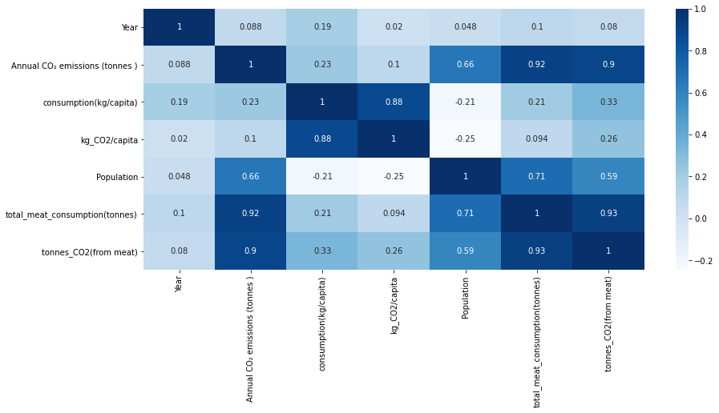

```python
# let's make a correlation map
sns.heatmap(meat_co2_pop.corr(), annot=True, cmap='Blues')
plt.show()
```

As expected, there are clear correlations between population and annual CO2 emissions as well as population and total_meat_consumption. In fact, many [millenials are opting out of having children](https://www.nbcnews.com/news/us-news/some-millennials-climate-change-clock-ticks-louder-biological-one-n993331) for this exact reason, in an attempt to reduce carbon emissions. As expected. there should also be a strong correlation (0.93), between total meat consumption and the tons of CO2 resulting from meat consumption.

Interestingly, there is a strong 0.92 correlation between the total amount of meat consumption and the Annual CO2 emissions produced (in general).

This does suggest that meat consumption does in fact play a significant role in CO2 production.

I would like to see this better maybe by choosing a country, like USA for example:

```python
USA = meat_co2_pop[meat_co2_pop['Code'] =='USA']
USA = USA.drop(['kg_CO2/capita', 'consumption(kg/capita)', 'Population'], axis=1)
# in order to plot these lines all together we are going to have to melt the data
melted_USA = pd.melt(USA, id_vars=["Entity", 'Code', 'Year'], var_name="CO2 Production", value_name="Tons Of CO2")
```

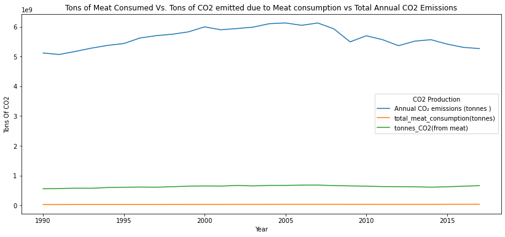

```python
line = sns.lineplot(data=melted_USA, x="Year", y='Tons Of CO2', hue='CO2 Production')
line.set_title("Tons of Meat Consumed Vs. Tons of CO2 emitted due to Meat consumption vs Total Annual CO2 Emissions")
```

As we can see by the line plot above, even though meat consumtion and the amount of annual CO2 emissions are highly correlated, the amount of CO2 actually produced as a result of meat consumption is only a fraction of the over all CO2 created. Additionally, because these values are so far apart it is hard to see any trends in meat consumption over time, and whether or not it is having any influence on total annual CO2 emissions.

Below, we will graph Annual CO2 Emissions per country, and CO2 emissions due to meat on 2 separate plots:

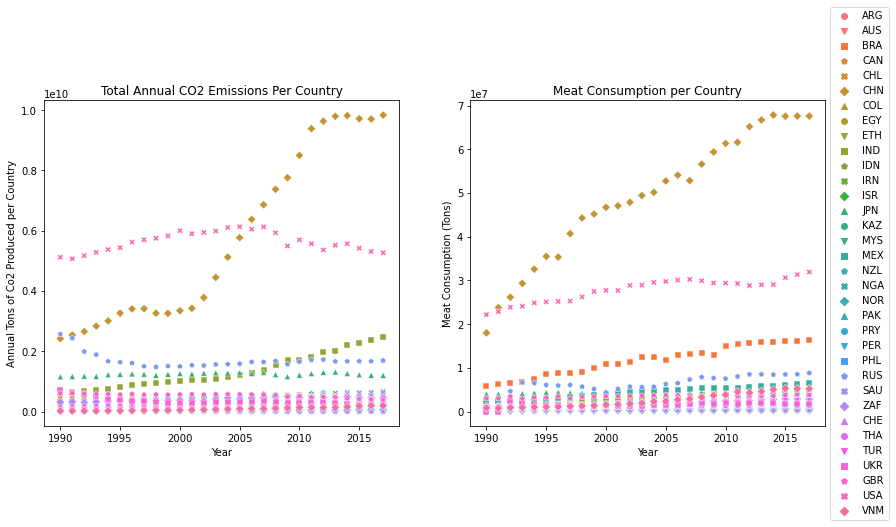

```python
#creating the markers to make it easier to differentiate between scatterplot points:
#get list of country codes
countries = meat_co2_pop['Code'].unique().tolist()
marker_list = ["o", "v", "s", "p","X", "D", "^"]
markers = dict()
counter = 0
for code in countries:
    if counter == len(marker_list):
        counter = 0
    markers[code] = marker_list[counter]
    counter+=1

plt.subplot(1, 2, 1) # row 1, col 2 index 1
sns.scatterplot(data=meat_co2_pop, x='Year', y='Annual CO₂ emissions (tonnes )', hue='Code', style='Code', markers=markers, legend=False)
#plt.plot(xPoints, y1Points)
plt.title("Total Annual CO2 Emissions Per Country")
plt.xlabel('Year')
plt.ylabel('Annual Tons of Co2 Produced per Country')

plt.subplot(1, 2, 2) # index 2
sns.scatterplot(data=meat_co2_pop, x='Year', y='total_meat_consumption(tonnes)', hue='Code', style='Code', markers=markers)
#plt.plot(xPoints, y1Points)
plt.title("Meat Consumption per Country")
plt.xlabel("Year")
plt.ylabel("Meat Consumption (Tons)")
#only need legend for 1 plot because it is the same for both
plt.legend(loc='center left', bbox_to_anchor=(1.0, 0.5))
```

In the charts above it is interesting to note that China and the United States seem to be the largest offenders when it comes to both CO2 produced and meat consumption. Additionally, it is interesting to observe that both CO2 emissions and meat consumption in the US have a mild slope, whereas both CO2 emissions and meat consumption in China have a pretty steep positive slope. Coincidence? Let's dive deeper.

Let's better analyze the correlation between meat consumption and total annual CO2 emissions by displaying them against each other on the same plot:

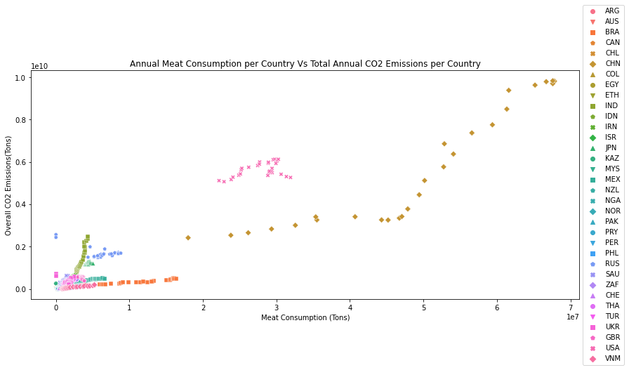

```python
sns.scatterplot(data=meat_co2_pop, x='total_meat_consumption(tonnes)', y='Annual CO₂ emissions (tonnes )', hue='Code', style='Code', markers=markers)
#plt.plot(xPoints, y1Points)
plt.title("Annual Meat Consumption per Country Vs Total Annual CO2 Emissions per Country")
plt.xlabel('Meat Consumption (Tons)')
plt.ylabel('Overall CO2 Emissions(Tons)')
plt.legend(loc='center left', bbox_to_anchor=(1.0, 0.5))
```

In this case, Meat Consumption is our independent variable (usually plotted on the x-axis), and we want to see what effect it has on our dependent variable, which is Total CO2 Emissions(plotted on the y-ax-s).

It is clear in this graph that each country is relatively grouped together when it comes to their indivudal meat consumption and CO2 emissions although they all seem to (mostly) positively slope upwards. Although there are a few exceptions, the main trend seems to be increasing, with China in the lead.

### Hypothesis Testing and Machine Learning

Remember, our hypothesis is that meat consumption does in fact play a role and can predict CO2 emissisons. Let's make our table simpler and keep only the variables we are interested in for creating our machine learning models.

```python
# I only want to keep meat consumption rather than tons of CO2 produced from meat because that was mostly just
# used as a visualization tool
meat_co2 = meat_co2_pop.drop(['consumption(kg/capita)', 'kg_CO2/capita', 'Code', 'tonnes_CO2(from meat)'], axis=1)
meat_co2
```

|  | Entity | Year | Annual CO₂ emissions (tonnes ) | Population | total_meat_consumption(tonnes) |
| --- | --- | --- | --- | --- | --- |
| 0 | Argentina | 1990 | 111890017.8 | 33035578 | 2.318272e+06 |
| 1 | Argentina | 1991 | 116845003.3 | 33504421 | 2.233271e+06 |
| 2 | Argentina | 1992 | 121016713.6 | 33966873 | 2.288960e+06 |
| 3 | Argentina | 1993 | 117564672.1 | 34407178 | 2.540626e+06 |
| 4 | Argentina | 1994 | 122010040.7 | 34846915 | 2.585537e+06 |
| ... | ... | ... | ... | ... | ... |
| 947 | Vietnam | 2013 | 140438875.8 | 93859918 | 4.606832e+06 |
| 948 | Vietnam | 2014 | 159712377.1 | 95031568 | 5.006928e+06 |
| 949 | Vietnam | 2015 | 184501879.2 | 96197851 | 5.269718e+06 |
| 950 | Vietnam | 2016 | 197801557.3 | 97355565 | 5.210957e+06 |
| 951 | Vietnam | 2017 | 198826548.8 | 98482273 | 5.233840e+06 |

952 rows × 5 columns

Because country does in fact seem to be interacting with our model (based off of the way they're grouped above) we will create dummy variables out of it in order to include it in our model. Pandas get_dummies() is very useful for turning categorical variables (our countries) into numerical variables for you to be used in regression models, but be careful not to fall in the [dummy variable trap!](https://parulpandey.com/2021/06/24/beware-of-the-dummy-variable-trap-in-pandas/) This can often be avoided by dropping the first column in order to avoid redundancy and multicolinearity.

```python
meat_co2 = pd.get_dummies(meat_co2, drop_first=True)
meat_co2
```

|  | Year | Annual CO₂ emissions (tonnes ) | Population | total_meat_consumption(tonnes) | Entity_Australia | Entity_Brazil | Entity_Canada | Entity_Chile | Entity_China | Entity_Colombia | ... | Entity_Russia | Entity_Saudi Arabia | Entity_South Africa | Entity_Switzerland | Entity_Thailand | Entity_Turkey | Entity_Ukraine | Entity_United Kingdom | Entity_United States | Entity_Vietnam |
| --- | --- | --- | --- | --- | --- | --- | --- | --- | --- | --- | --- | --- | --- | --- | --- | --- | --- | --- | --- | --- | --- |
| 0 | 1990 | 111890017.8 | 33035578 | 2.318272e+06 | 0 | 0 | 0 | 0 | 0 | 0 | ... | 0 | 0 | 0 | 0 | 0 | 0 | 0 | 0 | 0 | 0 |
| 1 | 1991 | 116845003.3 | 33504421 | 2.233271e+06 | 0 | 0 | 0 | 0 | 0 | 0 | ... | 0 | 0 | 0 | 0 | 0 | 0 | 0 | 0 | 0 | 0 |
| 2 | 1992 | 121016713.6 | 33966873 | 2.288960e+06 | 0 | 0 | 0 | 0 | 0 | 0 | ... | 0 | 0 | 0 | 0 | 0 | 0 | 0 | 0 | 0 | 0 |
| 3 | 1993 | 117564672.1 | 34407178 | 2.540626e+06 | 0 | 0 | 0 | 0 | 0 | 0 | ... | 0 | 0 | 0 | 0 | 0 | 0 | 0 | 0 | 0 | 0 |
| 4 | 1994 | 122010040.7 | 34846915 | 2.585537e+06 | 0 | 0 | 0 | 0 | 0 | 0 | ... | 0 | 0 | 0 | 0 | 0 | 0 | 0 | 0 | 0 | 0 |
| ... | ... | ... | ... | ... | ... | ... | ... | ... | ... | ... | ... | ... | ... | ... | ... | ... | ... | ... | ... | ... | ... |
| 947 | 2013 | 140438875.8 | 93859918 | 4.606832e+06 | 0 | 0 | 0 | 0 | 0 | 0 | ... | 0 | 0 | 0 | 0 | 0 | 0 | 0 | 0 | 0 | 1 |
| 948 | 2014 | 159712377.1 | 95031568 | 5.006928e+06 | 0 | 0 | 0 | 0 | 0 | 0 | ... | 0 | 0 | 0 | 0 | 0 | 0 | 0 | 0 | 0 | 1 |
| 949 | 2015 | 184501879.2 | 96197851 | 5.269718e+06 | 0 | 0 | 0 | 0 | 0 | 0 | ... | 0 | 0 | 0 | 0 | 0 | 0 | 0 | 0 | 0 | 1 |
| 950 | 2016 | 197801557.3 | 97355565 | 5.210957e+06 | 0 | 0 | 0 | 0 | 0 | 0 | ... | 0 | 0 | 0 | 0 | 0 | 0 | 0 | 0 | 0 | 1 |
| 951 | 2017 | 198826548.8 | 98482273 | 5.233840e+06 | 0 | 0 | 0 | 0 | 0 | 0 | ... | 0 | 0 | 0 | 0 | 0 | 0 | 0 | 0 | 0 | 1 |

952 rows × 37 columns

```python
# let's assign our independent and dependent variables
y = meat_co2['Annual CO₂ emissions (tonnes )']
X = meat_co2.drop('Annual CO₂ emissions (tonnes )',axis=1)
X.shape, y.shape
```

```
((952, 36), (952,))
```

We will be using an 80-20% train-test split to train and test our data.

```python
X_train, X_test, y_train, y_test = train_test_split(X, y, test_size=0.2, random_state=5)
```

Now we will build a linear regression model using our split data and we will score it by obtaining its [coefficient of determination (R^2)](https://byjus.com/maths/coefficient-of-determination/) and [root mean squared error (RMSE)](https://www.statology.org/how-to-interpret-rmse/) in order to assess how effective our model is.

```python
from sklearn.metrics import mean_squared_error
# fitting the model
reg = LinearRegression()
reg.fit(X_train, y_train)

# predicting outputs using our samples
predicted_test = reg.predict(X_test)
predicted_train = reg.predict(X_train)

# scoring the model
train_score = reg.score(X_train, y_train)
train_test = reg.score(X_test, y_test)

#computing mean squared error
mse_training = np.sqrt(mean_squared_error(y_train, predicted_train))
mse_testing = np.sqrt(mean_squared_error(y_test, predicted_test))

print("Linear Regression score on training Data: {:.3f}".format(train_score))
print("Linear Regression score on test Data: {:.3f}".format(train_test))
print('\nLinear Regression mean squared error of training:', mse_training)
print('Linear Regression mean squared error of testing:', mse_testing)
```

```
Linear Regression score on training Data: 0.970
Linear Regression score on test Data: 0.967

Linear Regression mean squared error of training: 243619583.97960508
Linear Regression mean squared error of testing: 256398012.40022048
```

Based on the linear regression score, it looks like our model does a good job of predicting annual CO2 emmissions. The mean squared error is quite high but we have to remember the huge kinds of numbers we are working with which might explain the large root mean squared error.

Still, let's try a Random Forest model as well to see if we can do this error. Once again, sklearn makes this quite easy for us. We can use our train/test split from above to build our model.

```python
from sklearn.ensemble import RandomForestRegressor

rf = RandomForestRegressor().fit(X_train, y_train)

# scoring the model
train_score = reg.score(X_train, y_train)
train_test = reg.score(X_test, y_test)

#computing mean squared error
mse_training = np.sqrt(mean_squared_error(y_train, rf.predict(X_train)))
mse_testing = np.sqrt(mean_squared_error(y_test, rf.predict(X_test)))

print("Random Forest score on training Data: {:.3f}".format(train_score))
print("Random Forest score on test Data: {:.3f}".format(train_test))
print('\nRandom Forest mean squared error of training:', mse_training)
print('Random Forest mean squared error of testing:', mse_testing)
```

```
Random Forest score on training Data: 0.970
Random Forest score on test Data: 0.967

Random Forest mean squared error of training: 37943311.545035236
Random Forest mean squared error of testing: 38922225.79987312
```

The root mean squared error of the Random Forest Model is much better than the linear regression model so this is the model we will ultimately choosing. It is important to test out a variety of models and comparing them against each other when you are choosing a model for your data. SKlearns random forest fodel also has a ["feature_importances_"](https://scikit-learn.org/stable/auto_examples/ensemble/plot_forest_importances.html) property which measures and can help us visualize exactly how much a variable is used in each tree of the forest and thus its 'importance' in the model.

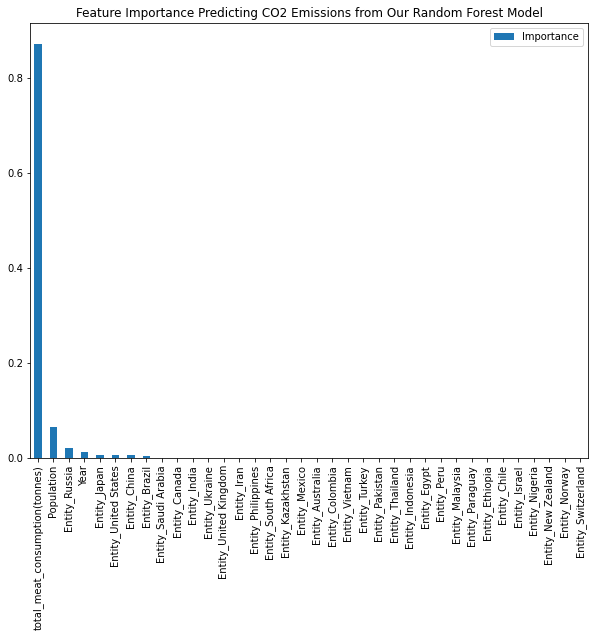

```python
importance = pd.DataFrame(rf.feature_importances_, index=X_train.columns, columns=["Importance"])
importance.sort_values(by='Importance', ascending=False, inplace=True)
bar = importance.plot(kind='bar', figsize=(10,8))
bar.set_title('Feature Importance Predicting CO2 Emissions from Our Random Forest Model')
```

As displayed above by the feature importances of our Random Forest Model, we can see that meat consumption has an importance of over 80%! Beating out population by an importance of over 60%! This was quite surprising to me, because while many millenials have been reportedly hesitant to have kids these days due to environmental conerns, it seems that according to our model, meat consumption has a much greater impact when it comes to your carbon footprint.

## Conclusion

Based off the results displayed above, I think it is safe to reject the null and confirm the hypothesis that CO2 emissions can in fact be predicted by meat consumption. We were able to create a succesful model wich predicts CO2 emission using meat consumption, showing that it is definitely a factor (among others of course), that may be accelerating climate change. Of course, it would be interesting to see if a similar model could be made if we were to repeat this process with all the plant-based food products! But, I'd still argue that meat consumption clearly has a more significant impact on CO2 emissions than a plant-based diet would have.

Originally, I would have liked to also get data on the actual amount of vegans/vegetarians there are globally, and see if a positive trend in veganism could somehow predict a decrease in CO2 emissions. But unfortunately, this data is very hard to find and likely inaccurate. Although this data is most likely MAR (missing at random), it is even possibly in some cases it could be MNAR. Food is so important in culture and in our societies that it can be a sensitive subject to breach. I think it is definitely hard to be vegan/vegetarian, as sometimes there is definitely a stigma against it. Although the world is starting to include more and more plant-based options, it is still hard to avoid judgement when you show up at a BBQ with your veggie patties. Maybe I perhaps would be more likely to go plant-based if the world made it easier. I would have liked to see more clearly if there is in fact an impact that can be made on an individual basis even though clearly most of the world is definitely not vegan or vegetarian. It would likely still take a very significant amount of people to become fully vegan in order to really make an impact on carbon emissions. That's why maybe a more realistic approach is to have everybody reduce their consumption a little, without necessarily becoming full blown vegetarian or abandoning absolutely all animal products. I still chose to keep the somewhat click-baity title though, because again, I thought it was fun.

### Resources

Resources have been hyper linked throughout the tutorial but they are again for your convenience:

- https://www.standard.co.uk/lifestyle/no-kids-better-for-the-environment-a4198451.html
- https://www.nbcnews.com/news/us-news/some-millennials-climate-change-clock-ticks-louder-biological-one-n993331
- https://parulpandey.com/2021/06/24/beware-of-the-dummy-variable-trap-in-pandas/
- https://byjus.com/maths/coefficient-of-determination/
- https://www.statology.org/how-to-interpret-rmse/
- https://scikit-learn.org/stable/auto_examples/ensemble/plot_forest_importances.html